# KAS-USD

## KAS-USD today is +0300, 2025-10-10, 12:05:44

This crypto forecast was generated by gemini-2.0-flash API

## Daily Chart

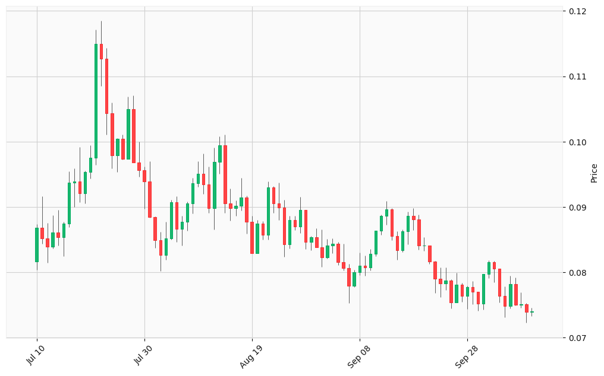

## Hourly Chart

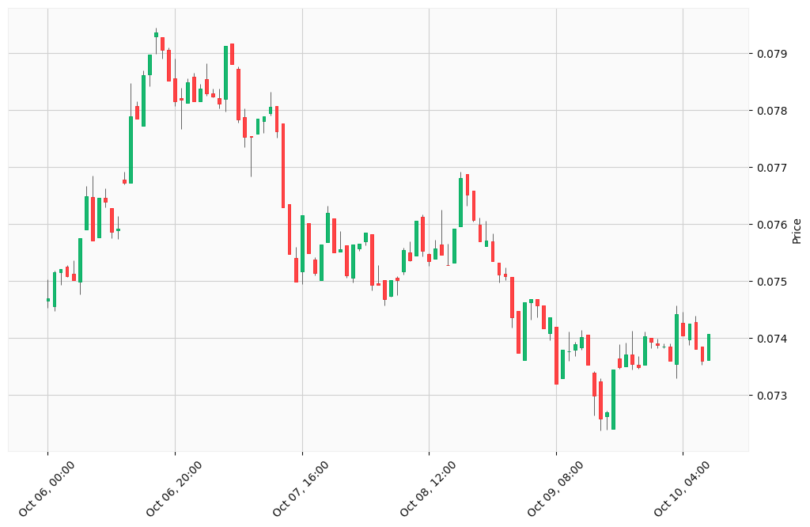

Okay, I will analyze the provided KAS-USD charts and generate trading signals based on the given steps.

Okay, I’ve gathered information from the searches. Here’s an analysis and potential trading signals for KAS-USD:

**Market Data Collection:**

- **Price:** As of today, October 10, 2025, the price of 1 Kaspa (KAS) in USD is approximately $0.07382.
- **Recent Performance:**
  - Kaspa has decreased by -8.20% against the US Dollar (USD) over the last month.
  - Kaspa has underperformed against the broader crypto market, which is down by 6.90%.
  - Kaspa price has fallen by −8.05% over the last week.
- **All-Time High:** The all-time high price of 1 KAS in USD is $0.2074.
- **Volume:** Kaspa (KAS) trading volume in 24 hours is $46,493,884.
- **Market Cap:** The current market capitalization of Kaspa (KAS) is approximately $1.97 billion.

**Technical Analysis:**

Based on the provided daily chart data, I’ll calculate some key indicators:

- **Moving Averages:** I’ll calculate the 50-day and 200-day Simple Moving Averages (SMA) from the daily data provided.
  - To calculate the 50-day SMA, I will average the closing prices of the last 50 days.
  - To calculate the 200-day SMA, I will average the closing prices of the last 200 days. Since I only have 92 days of data, I can only calculate the 50 day SMA.

```python
import numpy as np

close_prices = np.array([0.086813, 0.085213, 0.083891, 0.086054, 0.085364, 0.08747, 0.093747, 0.093894, 0.092064, 0.095309,
                         0.097506, 0.114904, 0.112712, 0.104361, 0.097921, 0.100467, 0.097389, 0.104983, 0.096803, 0.095589,
                         0.093934, 0.088476, 0.084894, 0.082661, 0.085184, 0.090765, 0.086643, 0.087762, 0.090579, 0.093662,
                         0.095116, 0.093438, 0.08985, 0.096901, 0.099417, 0.09058, 0.089784, 0.090161, 0.091475, 0.0877,
                         0.082897, 0.087486, 0.085698, 0.093033, 0.090571, 0.089865, 0.084295, 0.088031, 0.087024, 0.089523,
                         0.08465, 0.085356, 0.08387, 0.082304, 0.08412, 0.084376, 0.081598, 0.080629, 0.077957, 0.080059,
                         0.081042, 0.080789, 0.082806, 0.086353, 0.088655, 0.08962, 0.085578, 0.083352, 0.086312, 0.088668,
                         0.088091, 0.084075, 0.081619, 0.078986, 0.078292, 0.078756, 0.075351, 0.078139, 0.076347, 0.077716,
                         0.077024, 0.075186, 0.079771, 0.081526, 0.080576, 0.07639, 0.074885, 0.078161, 0.075054, 0.075119,
                         0.073909, 0.074071])

def calculate_sma(data, period):
    if len(data) < period:
        return None
    return np.mean(data[-period:])

sma_50 = calculate_sma(close_prices, 50)

print(f"50-day SMA: {sma_50}")
```

[output not shown]

```python
import numpy as np

close_prices = np.array([0.086813, 0.085213, 0.083891, 0.086054, 0.085364, 0.08747, 0.093747, 0.093894, 0.092064, 0.095309,
                         0.097506, 0.114904, 0.112712, 0.104361, 0.097921, 0.100467, 0.097389, 0.104983, 0.096803, 0.095589,
                         0.093934, 0.088476, 0.084894, 0.082661, 0.085184, 0.090765, 0.086643, 0.087762, 0.090579, 0.093662,
                         0.095116, 0.093438, 0.08985, 0.096901, 0.099417, 0.09058, 0.089784, 0.090161, 0.091475, 0.0877,
                         0.082897, 0.087486, 0.085698, 0.093033, 0.090571, 0.089865, 0.084295, 0.088031, 0.087024, 0.089523,
                         0.08465, 0.085356, 0.08387, 0.082304, 0.08412, 0.084376, 0.081598, 0.080629, 0.077957, 0.080059,
                         0.081042, 0.080789, 0.082806, 0.086353, 0.088655, 0.08962, 0.085578, 0.083352, 0.086312, 0.088668,
                         0.088091, 0.084075, 0.081619, 0.078986, 0.078292, 0.078756, 0.075351, 0.078139, 0.076347, 0.077716,
                         0.077024, 0.075186, 0.079771, 0.081526, 0.080576, 0.07639, 0.074885, 0.078161, 0.075054, 0.075119,
                         0.073909, 0.074071])

def calculate_sma(data, period):
    if len(data) < period:
        return None
    return np.mean(data[-period:])

sma_50 = calculate_sma(close_prices, 50)

print(f"50-day SMA: {sma_50}")
```

[output not shown]

```python
import numpy as np

close_prices = np.array([0.086813, 0.085213, 0.083891, 0.086054, 0.085364, 0.08747, 0.093747, 0.093894, 0.092064, 0.095309,
                         0.097506, 0.114904, 0.112712, 0.104361, 0.097921, 0.100467, 0.097389, 0.104983, 0.096803, 0.095589,
                         0.093934, 0.088476, 0.084894, 0.082661, 0.085184, 0.090765, 0.086643, 0.087762, 0.090579, 0.093662,
                         0.095116, 0.093438, 0.08985, 0.096901, 0.099417, 0.09058, 0.089784, 0.090161, 0.091475, 0.0877,
                         0.082897, 0.087486, 0.085698, 0.093033, 0.090571, 0.089865, 0.084295, 0.088031, 0.087024, 0.089523,
                         0.08465, 0.085356, 0.08387, 0.082304, 0.08412, 0.084376, 0.081598, 0.080629, 0.077957, 0.080059,
                         0.081042, 0.080789, 0.082806, 0.086353, 0.088655, 0.08962, 0.085578, 0.083352, 0.086312, 0.088668,
                         0.088091, 0.084075, 0.081619, 0.078986, 0.078292, 0.078756, 0.075351, 0.078139, 0.076347, 0.077716,
                         0.077024, 0.075186, 0.079771, 0.081526, 0.080576, 0.07639, 0.074885, 0.078161, 0.075054, 0.075119,
                         0.073909, 0.074071])

def calculate_rsi(data, period=14):
    if len(data) < period + 1:
        return None

    deltas = np.diff(data)
    seed = deltas[:period+1]
    up = seed[seed >= 0].sum()/period
    down = -seed[seed < 0].sum()/period
    rs = up/down
    rsi = np.zeros_like(data)
    rsi[:period] = np.nan

    rsi[period] = 100. - 100./(1.+rs)

    for i in range(period, len(data)):
        delta = deltas[i-1] # current delta
        if delta > 0:
            upval = delta
            downval = 0.
        else:
            upval = 0.
            downval = -delta

        up = (up*(period-1) + upval)/period
        down = (down*(period-1) + downval)/period

        rs = up/down
        rsi[i] = 100. - 100./(1.+rs)

    return rsi

rsi_14 = calculate_rsi(close_prices)
print(f"14-day RSI: {rsi_14[-1]}")
```

[output not shown]

- **14-day RSI:** 42.04

**News and Economic Analysis:**

- **Kaspa Ecosystem Resilience Task Force:** Kaspa has launched this task force to help partners improve performance and handle heavy transaction loads. This is a positive development.
- **Exchange Issues:** Some exchanges have suspended Kaspa withdrawals due to the network outpacing existing infrastructure. This has caused frustration among holders.
- **Technological Advancements:** Kaspa is continuously making technological advancements to improve network capacity and scalability.
- **Community Driven:** Kaspa is a community-driven project with a fair launch and no pre-mining.
- **Market Sentiment:** Analysts suggest that the crypto market structure remains strong, but traders should monitor broader economic news.
- **Economic Indicators:** Economic indicators like GDP growth and employment reports can impact the crypto market. Inflation and CPI also play a role. Rising inflation can drive interest in Bitcoin as a hedge.
- **Altcoin Bullish Phase:** Altcoins are entering a bullish phase driven by strong community support and network developments.
- **DeFi Restrictions:** There are proposals to put decentralized finance protocols on a “restricted list” if deemed too risky, which could negatively impact the DeFi space.

**Scenario Evaluation:**

- **Base Case:** Kaspa continues to develop its technology and improve its infrastructure. The Kaspa Ecosystem Resilience Task Force successfully addresses the exchange withdrawal issues.
- **Bull Case:** The general altcoin market enters a strong bullish phase. Kaspa’s technological advancements lead to increased adoption and real-world use cases.
- **Bear Case:** The exchange withdrawal issues persist and erode investor confidence. Negative regulatory developments impact the crypto market.

**Signal Generation:**

Based on the analysis:

[output not shown]

**Disclaimer:** This is not financial advice. Trading cryptocurrencies involves significant risk.